# Lesson 4

### Scatterplots and Perceived Audience Size

Notes: 04/18/2015

### Scatterplots

Notes:

```r
pf <- read.csv("D:/EDA/R_wd/L4/pseudo_facebook.tsv", sep = '\t')
str(pf)
```

```
## 'data.frame':    99003 obs. of  15 variables:
##  $ userid               : int  2094382 1192601 2083884 1203168 1733186 1524765 1136133 1680361 1365174 1712567 ...
##  $ age                  : int  14 14 14 14 14 14 13 13 13 13 ...
##  $ dob_day              : int  19 2 16 25 4 1 14 4 1 2 ...
##  $ dob_year             : int  1999 1999 1999 1999 1999 1999 2000 2000 2000 2000 ...
##  $ dob_month            : int  11 11 11 12 12 12 1 1 1 2 ...
##  $ gender               : Factor w/ 2 levels "female","male": 2 1 2 1 2 2 2 1 2 2 ...
##  $ tenure               : int  266 6 13 93 82 15 12 0 81 171 ...
##  $ friend_count         : int  0 0 0 0 0 0 0 0 0 0 ...
##  $ friendships_initiated: int  0 0 0 0 0 0 0 0 0 0 ...
##  $ likes                : int  0 0 0 0 0 0 0 0 0 0 ...
##  $ likes_received       : int  0 0 0 0 0 0 0 0 0 0 ...
##  $ mobile_likes         : int  0 0 0 0 0 0 0 0 0 0 ...
##  $ mobile_likes_received: int  0 0 0 0 0 0 0 0 0 0 ...
##  $ www_likes            : int  0 0 0 0 0 0 0 0 0 0 ...
##  $ www_likes_received   : int  0 0 0 0 0 0 0 0 0 0 ...
```

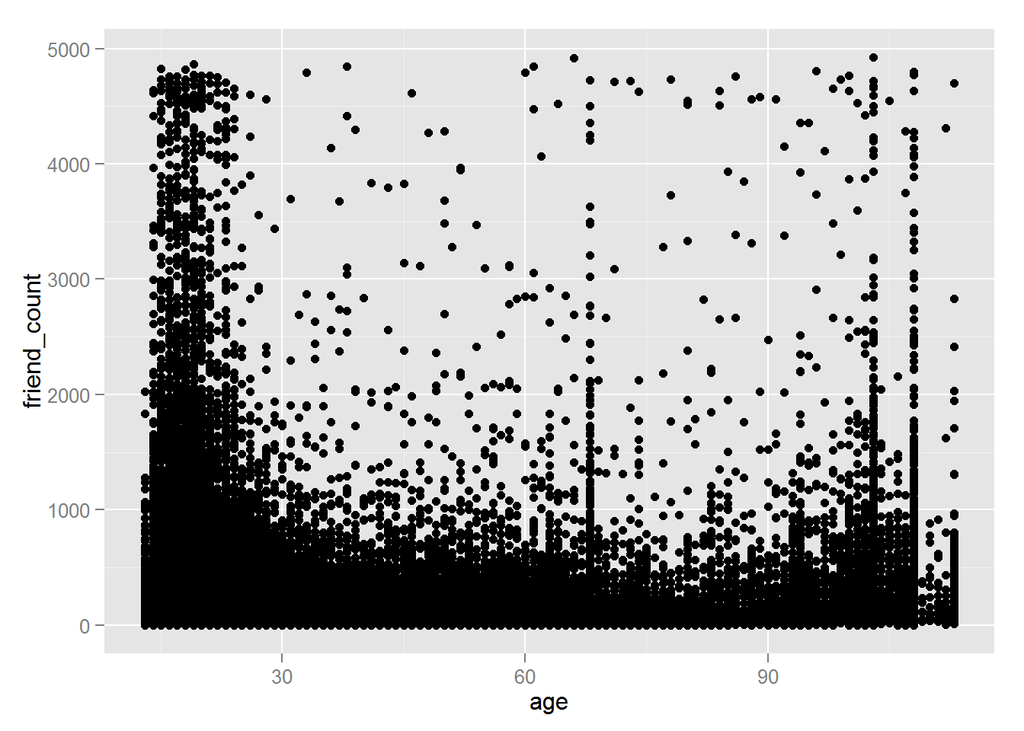

```r
library(ggplot2)
qplot(data = pf, x = age, y = friend_count)
```

#### What are some things that you notice right away?

Response: - Young people (< 30years) seem to have people with extremely large number of friends upto 5000 - Mostly, other age groups have less than 1000 friends. - Also some spikes for ~68 and again for 100+. Are there really people who are that old? Unlikely

### ggplot Syntax

Notes: http://www.ceb-institute.org/bbs/wp-content/uploads/2011/09/handout_ggplot2.pdf - Limit age to (13, 90) based on min age and based on fact that we don’t believe FB has some many users above 90yrs - Unlike gplot(), with ggplot(), you always have to explicitly specify geom_*()

```r
summary(pf$age)
```

```
##    Min. 1st Qu.  Median    Mean 3rd Qu.    Max.
##   13.00   20.00   28.00   37.28   50.00  113.00
```

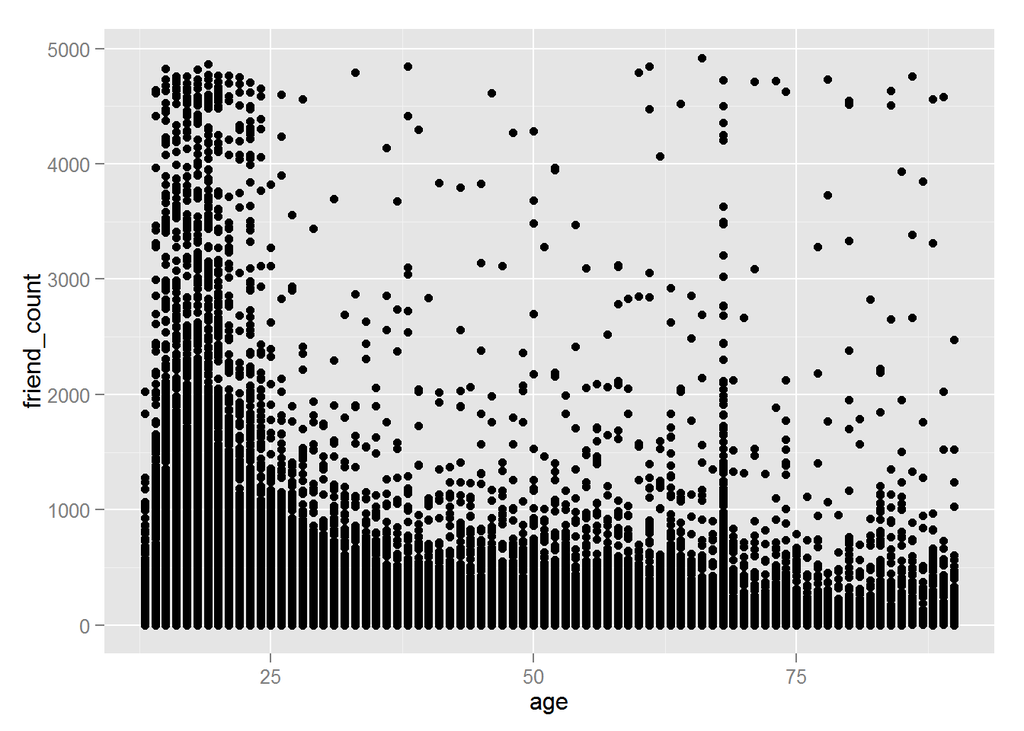

```r
ggplot(data = pf, aes(x = age, y = friend_count)) +
  geom_point() +
  xlim(13, 90)
```

### Overplotting

Notes: - Some of the points, towards the bottom are so closely packed, we can’t really tell density - Introduce alpha component for pixel intensity (alpha = 1/x) means x points needed to make a solid point - Introduce jitter because age is not a perfect integer

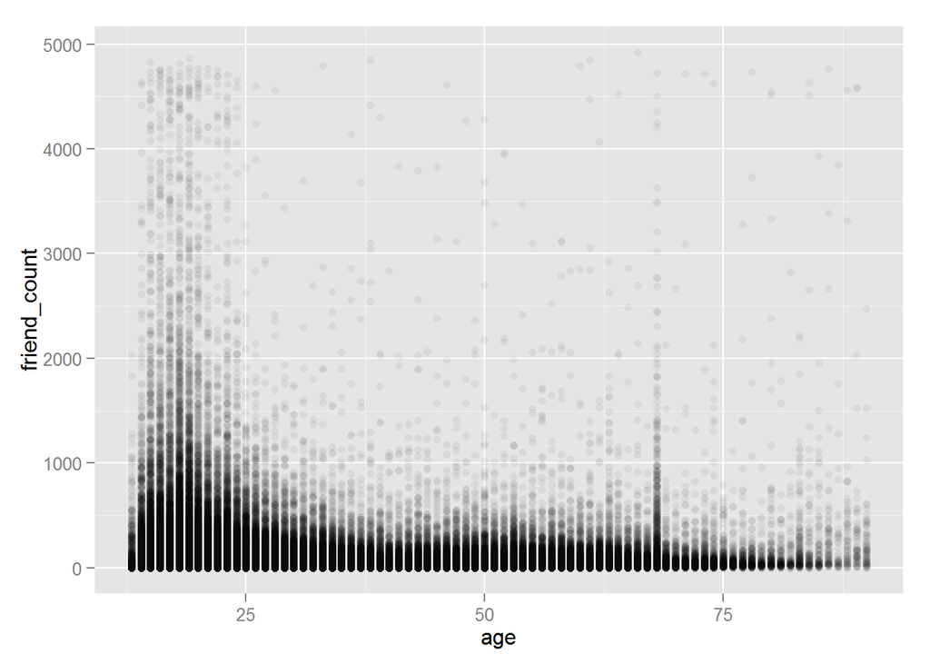

```r
ggplot(data = pf, aes(x = age, y = friend_count)) +
  geom_point(alpha = 1/20) +
  xlim(13, 90)
```

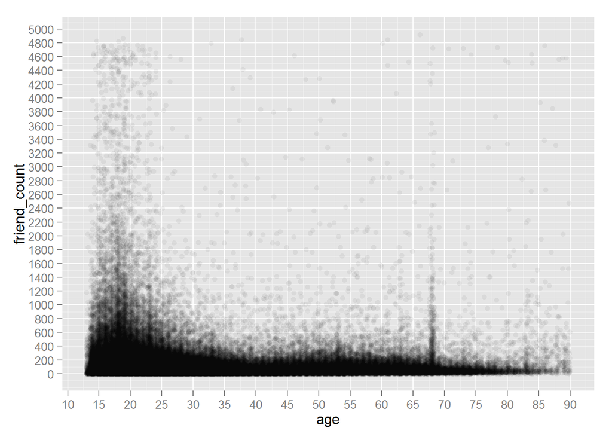

```r
ggplot(data = pf, aes(x = age, y = friend_count)) +
  geom_jitter(alpha = 1/20) +
  scale_x_continuous(limits = c(13, 90), breaks = seq(10, 90, 5)) +
  scale_y_continuous(breaks = seq(0, 5000, 200))
```

### Coord_trans()

Notes: http://docs.ggplot2.org/current/coord_trans.html - Transform y axis to look at it better using sqrt

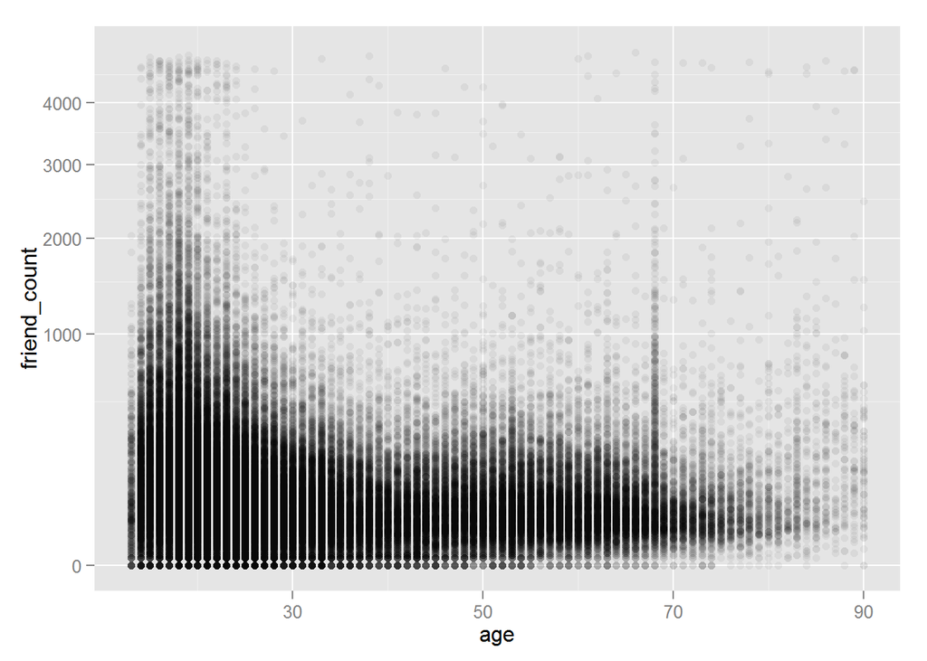

```r
ggplot(data = pf, aes(x = age, y = friend_count)) +
  geom_point(alpha = 1/20) +
  xlim(13, 90) +
  coord_trans(y = "sqrt")
```

#### What do you notice? Response - Didn’t work with geom_jitter(). Had to use geom_point(). - Lines became fainter close to y = 0 indicating that there are very few accounts with close to 0 friends.

#### Look up the documentation for coord_trans() and add a layer to the plot that transforms friend_count using the square root function with jitter. Create your plot!

Notes: - Notice that just using geom_jitter() adds jitter to friend count as well. For accounts with zero users, jitter can make friend_count -ve and sqrt(-ve) will break down

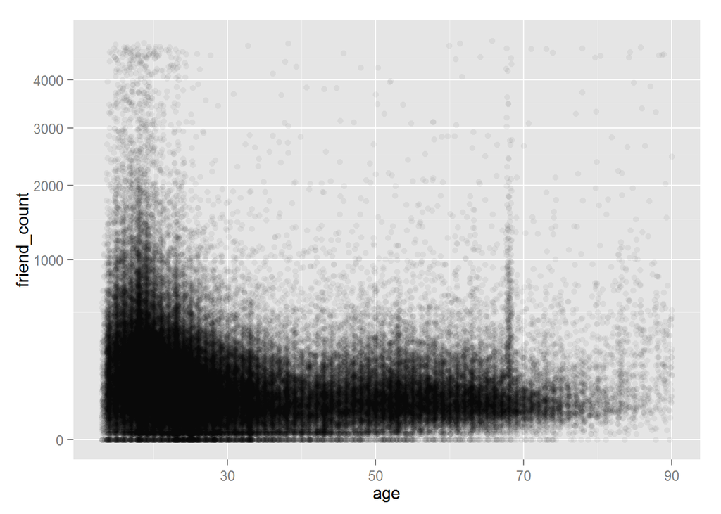

```r
# h = 0 specifies that even after y jitter, limit min value of y to 0
ggplot(data = pf, aes(x = age, y = friend_count)) +
  geom_point(alpha = 1/20, position = position_jitter(h = 0)) +
  xlim(13, 90) +
  coord_trans(y = "sqrt")
```

### Alpha and Jitter

Explore the relationship between friends_initiated and age Notes:

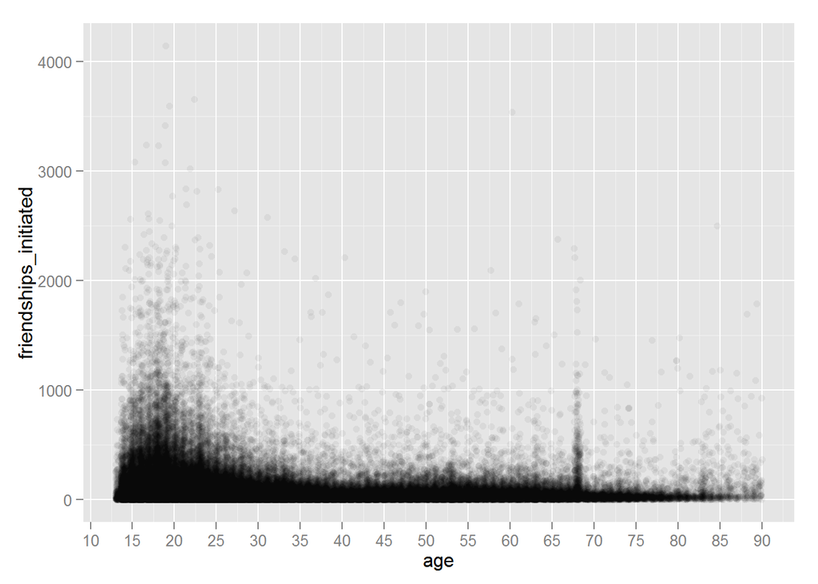

```r
ggplot(aes(x = age, y = friendships_initiated), data = pf) +
  geom_point(alpha = 1/20, position = position_jitter(h = 0)) +
  scale_x_continuous(limits = c(13, 90), breaks = seq(10, 90, 5))
```

```r
summary(pf$friendships_initiated)       # median 46
```

```
##    Min. 1st Qu.  Median    Mean 3rd Qu.    Max.
##     0.0    17.0    46.0   107.5   117.0  4144.0
```

Notes: - We see that friendships_initiated is lot less than friend_count - This makes sense because if a user has x friends, we can assume roughly x/2 intiated by user and x/2 are requests to user. - In fact, we saw median for friend_count was 82 and for friendships_initiated it is 46

### Dplyr package

Notes: http://rstudio-pubs-static.s3.amazonaws.com/11068_8bc42d6df61341b2bed45e9a9a3bf9f4.html Video: http://www.r-bloggers.com/hadley-wickham-presents-dplyr-at-user-2014/ ***

### Conditional Means

Notes: We want to be able to see measures of center variations instead of looking at each point - Since age goes all the way from 13, 90, its not a good idea to do this using boxplot or histogram for each age. (That would make it 90 different plots) - So we will transform data to calculate the mean and median of friend counts by age and use that - Think of dplyr helping in aggregation functions that we see in SQL

```r
library('dplyr')
# Does nothing but group observations together by age
pf.by_age <- group_by(pf, age)
head(pf.by_age)
```

```
## Source: local data frame [6 x 15]
## Groups: age
##
##    userid age dob_day dob_year dob_month gender tenure friend_count
## 1 2094382  14      19     1999        11   male    266            0
## 2 1192601  14       2     1999        11 female      6            0
## 3 2083884  14      16     1999        11   male     13            0
## 4 1203168  14      25     1999        12 female     93            0
## 5 1733186  14       4     1999        12   male     82            0
## 6 1524765  14       1     1999        12   male     15            0
## Variables not shown: friendships_initiated (int), likes (int),
##   likes_received (int), mobile_likes (int), mobile_likes_received (int),
##   www_likes (int), www_likes_received (int)
```

```r
# NOTE that summarise() is different from summary()
pf.fc_by_age <- summarise(pf.by_age,
                          fc_mean = mean(friend_count),
                          fc_median = median(friend_count),
                          n = n())
# for some reason, I already see summarise arranging in order (by accident?)
head(pf.fc_by_age)
```

```
## Source: local data frame [6 x 4]
##
##   age  fc_mean fc_median    n
## 1  13 164.7500      74.0  484
## 2  14 251.3901     132.0 1925
## 3  15 347.6921     161.0 2618
## 4  16 351.9371     171.5 3086
## 5  17 350.3006     156.0 3283
## 6  18 331.1663     162.0 5196
```

```r
pf.fc_by_age <- arrange(pf.fc_by_age, age)
head(pf.fc_by_age)
```

```
## Source: local data frame [6 x 4]
##
##   age  fc_mean fc_median    n
## 1  13 164.7500      74.0  484
## 2  14 251.3901     132.0 1925
## 3  15 347.6921     161.0 2618
## 4  16 351.9371     171.5 3086
## 5  17 350.3006     156.0 3283
## 6  18 331.1663     162.0 5196
```

```r
str(pf.fc_by_age)
```

```
## Classes 'tbl_df', 'tbl' and 'data.frame':    101 obs. of  4 variables:
##  $ age      : int  13 14 15 16 17 18 19 20 21 22 ...
##  $ fc_mean  : num  165 251 348 352 350 ...
##  $ fc_median: num  74 132 161 172 156 ...
##  $ n        : int  484 1925 2618 3086 3283 5196 4391 3769 3671 3032 ...
```

```r
# Note that you CANNOT pipeline data tables or databases
pf.fc_by_age <- pf %>%
  group_by(age) %>%
  summarise(fc_mean = mean(friend_count),
            fc_median = median(friend_count),
            n = n()) %>%
  arrange(age)

head(pf.fc_by_age)
```

```
## Source: local data frame [6 x 4]
##
##   age  fc_mean fc_median    n
## 1  13 164.7500      74.0  484
## 2  14 251.3901     132.0 1925
## 3  15 347.6921     161.0 2618
## 4  16 351.9371     171.5 3086
## 5  17 350.3006     156.0 3283
## 6  18 331.1663     162.0 5196
```

Response: Note - When pipelining, we omit the data variable because dataframe is assumed to pipeline from previous stage to the next

### Create your plot!

Notes: - Since we have only one data point per mean, we are NOT dealing with frequencies - This means that histograms, freqplots & boxplots are out of the question http://docs.ggplot2.org/current/geom_line.html

```r
summary(pf.by_age$friend_count)
```

```
##    Min. 1st Qu.  Median    Mean 3rd Qu.    Max.
##     0.0    31.0    82.0   196.4   206.0  4923.0
```

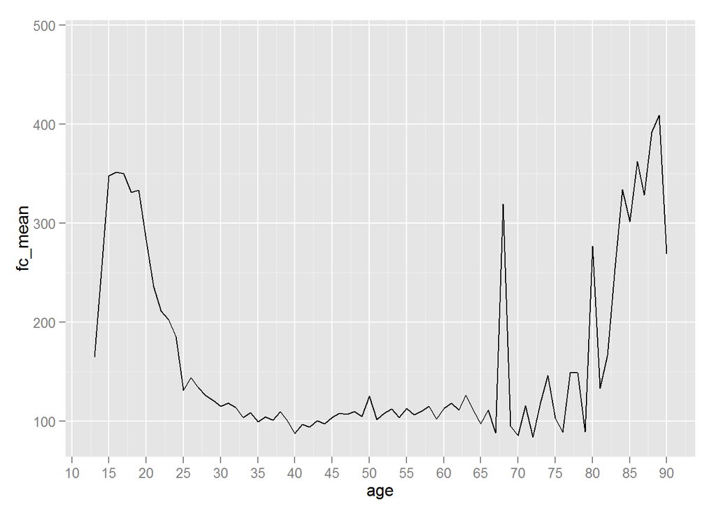

```r
ggplot(aes(x = age, y = fc_mean), data = pf.fc_by_age) +
  geom_line() +
  scale_x_continuous(limits = c(13, 90), breaks = seq(10, 90, 5))
```

### Overlaying Summaries with Raw Data

Notes: - Add mean, median, 10% and 90% quantiles on top of scatter plot to get a better sense of ranges - Wow, some really funky syntax. summary is in quotes, but not the function name mean!

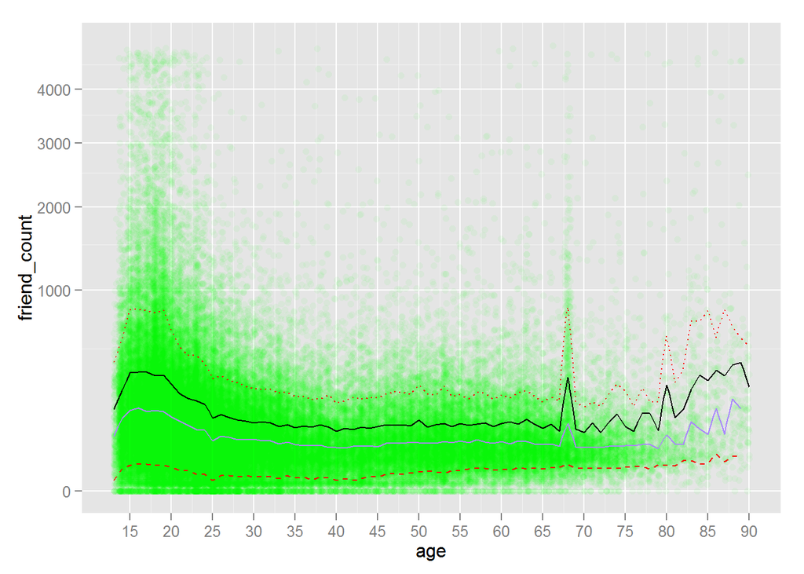

```r
ggplot(aes(x = age, y = friend_count), data = pf) +
  geom_point(alpha = 1/20, position = position_jitter(h = 0), color = 'green') +
  scale_x_continuous(limits = c(13, 90), breaks = seq(10, 90, 5)) +
  coord_trans(y = "sqrt") +
  geom_line(stat = "summary", fun.y = mean) +
  geom_line(stat = "summary", fun.y = median, color = I('#aa88ff')) +
  geom_line(stat = "summary", fun.y = quantile, probs = 0.1, color = I('red'), linetype = 2) +
  geom_line(stat = "summary", fun.y = quantile, probs = 0.9, color = I('red'), linetype = 3)
```

#### What are some of your observations of the plot?

Response: - Mean is higher than median which means long tailed to right (as we knew before) - There are quite a bit of outliers even above 90% quartile for younger age groups (ie stddev is high)

### Moira: Histogram Summary and Scatterplot

See the Instructor Notes of this video to download Moira’s paper on perceived audience size and to see the final plot.

Notes:

### Correlation

Notes: - Use cor.test to calculate pearson coefficient for age and friend count - From graph, we see that it is really a bell-curve relation between age & friend count - So, I am guessing pretty close to 0 or un-correlated

```r
pearson <- cor.test(x = pf$age, y = pf$friend_count)
pearson
```

```
##
##  Pearson's product-moment correlation
##
## data:  pf$age and pf$friend_count
## t = -8.6268, df = 99001, p-value < 2.2e-16
## alternative hypothesis: true correlation is not equal to 0
## 95 percent confidence interval:
##  -0.03363072 -0.02118189
## sample estimates:
##         cor
## -0.02740737
```

```r
r1 <- cor.test(x = pf$age, y = pf$friend_count, method = "kendall", conf.level = 0.95)
r1
```

```
##
##  Kendall's rank correlation tau
##
## data:  pf$age and pf$friend_count
## z = -50.8589, p-value < 2.2e-16
## alternative hypothesis: true tau is not equal to 0
## sample estimates:
##        tau
## -0.1091992
```

Look up the documentation for the cor.test function. What’s the correlation between age and friend count? Round to three decimal places.

Response: r = -0.027 Note how it is almost zero as expected.

### Correlation on Subsets

Notes: - Do the same thing with data frames using with() - If we blow away the higher ages (say >65), we can expect a -ve slope line and stronger correlation

```r
pearson2 <- with(pf, cor.test(age, friend_count, conf.level = 0.99))
pearson2
```

```
##
##  Pearson's product-moment correlation
##
## data:  age and friend_count
## t = -8.6268, df = 99001, p-value < 2.2e-16
## alternative hypothesis: true correlation is not equal to 0
## 99 percent confidence interval:
##  -0.03558573 -0.01922535
## sample estimates:
##         cor
## -0.02740737
```

```r
p.le_65 <- with(subset(pf, age <= 65), cor.test(age, friend_count, conf.level = 0.99))
p.le_65
```

```
##
##  Pearson's product-moment correlation
##
## data:  age and friend_count
## t = -56.2611, df = 88051, p-value < 2.2e-16
## alternative hypothesis: true correlation is not equal to 0
## 99 percent confidence interval:
##  -0.1946482 -0.1778897
## sample estimates:
##        cor
## -0.1862825
```

Response: Notice how we blew away about 11k observations (df went from 99k to 88k)

## Create Scatterplots

Notes: - Create a scatterplot of likes_received (y) vs. www_likes_received (x) - Obviously doesn’t make sense to add jitter here because likes are discrete - We zoom in based on summaries.

```r
summary(pf$www_likes_received)
```

```
##      Min.   1st Qu.    Median      Mean   3rd Qu.      Max.
##      0.00      0.00      2.00     58.57     20.00 130000.00
```

```r
summary(pf$likes_received)
```

```
##     Min.  1st Qu.   Median     Mean  3rd Qu.     Max.
##      0.0      1.0      8.0    142.7     59.0 261200.0
```

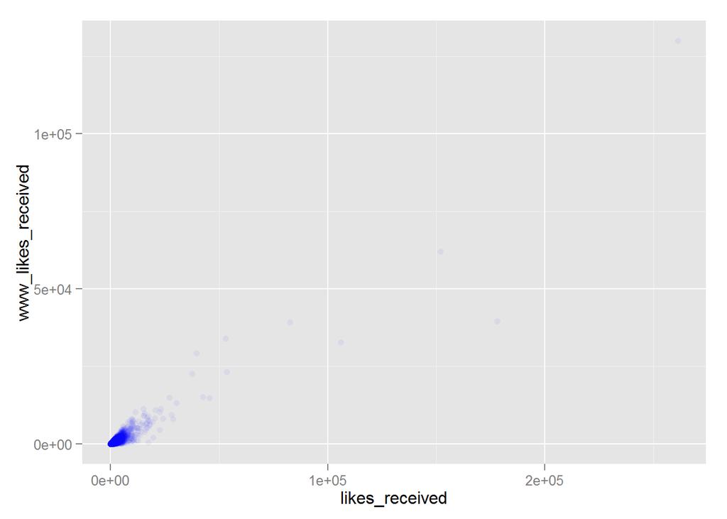

```r
ggplot(aes(y = www_likes_received, x = likes_received), data = pf) +
  geom_point(alpha = 1/20, color = 'blue')
```

Notes: - Bulk of data in lower left corner. Get rid of outliers by calculating 95% quantiles for x and y

### Strong Correlations

Notes: Also plot the straight line using linear regression

```r
xq <- with(pf, quantile(x = likes_received, probs = 0.95))
xq
```

```
## 95%
## 561
```

```r
yq <- with(pf, quantile(x = www_likes_received, probs = 0.95))
yq
```

```
## 95%
## 227
```

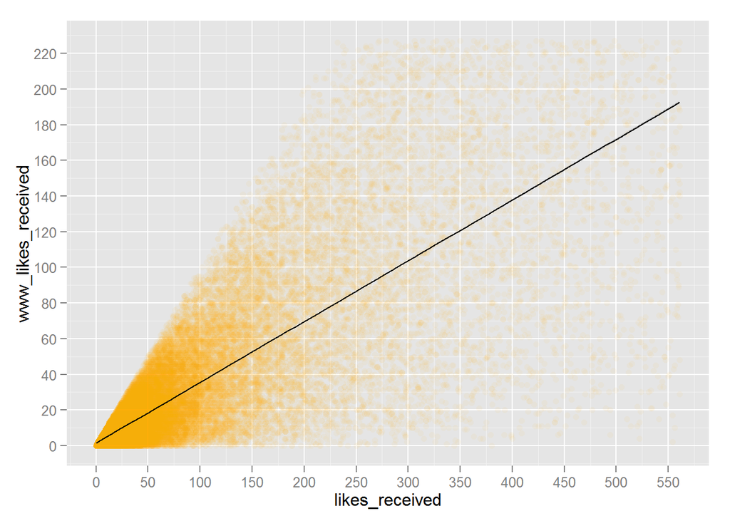

```r
# Use in setting limits
ggplot(aes(y = www_likes_received, x = likes_received), data = pf) +
  geom_point(alpha = 1/20, color = 'orange') +
  scale_y_continuous(limits = c(0, 227), breaks = seq(0, 227, 20)) +
  scale_x_continuous(limits = c(0, 561), breaks = seq(0, 561, 50)) +
  geom_smooth(method = 'lm', color = 'black')
```

Response: - From scatterplot, we expect r to come in very close to 1

What’s the correlation betwen the two variables? Include the top 5% of values for the variable in the calculation and round to 3 decimal places.

```r
with(pf, cor.test(likes_received, www_likes_received))
```

```
##
##  Pearson's product-moment correlation
##
## data:  likes_received and www_likes_received
## t = 937.1035, df = 99001, p-value < 2.2e-16
## alternative hypothesis: true correlation is not equal to 0
## 95 percent confidence interval:
##  0.9473553 0.9486176
## sample estimates:
##       cor
## 0.9479902
```

Response:

### Moira on Correlation

Notes: - As we already noted, if we use perfectly correlated variables as features for linear regression, it will never converge on a solution. When you use matrices, inverse will not exist. - Basically need to identify and get rid of redundant features to get rid of the issue.

```r
# install.packages('alr3')
library(alr3)
```

Create your plot!

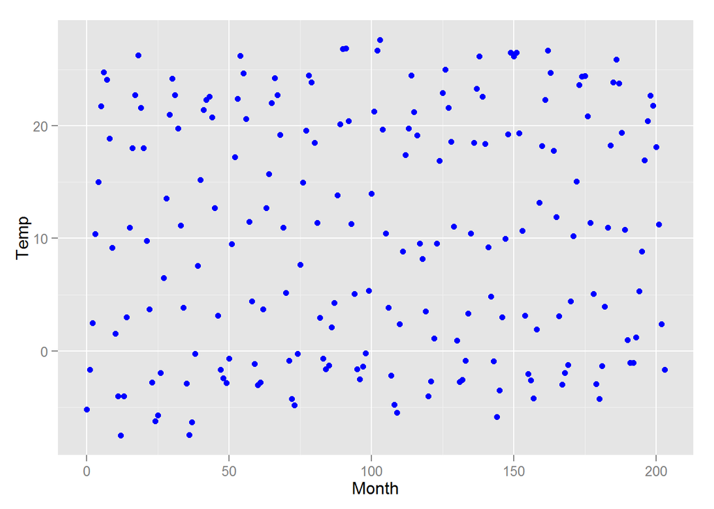

```r
ggplot(aes(y = Temp, x = Month), data = Mitchell) +
  geom_point(color = 'blue')
```